# Personal Youtube Ad Analysis

## About the data I have gathered.

For this project, I have gathered some data about the different ads I have been receiving when watching YouTube videos. The plots below will show how the different variables I have gathered relate to each other, which gives me some interesting insight in the types of ads I get.

.

## Mean Rating for Each Genre of Ads:

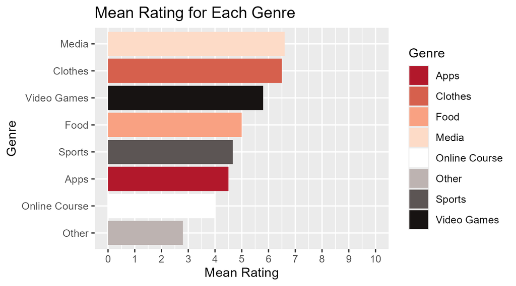

The top 3 highest mean rated genres were Media, Clothing, and Video Games. All three of these are personal hobbies of mine, which made sense why I rated them so highly. From what I remember, most of the ads from these genres did a really good job seling their products to me and since I am already interested in the genre, it further attracted me to these ads. The lowest mean ratings of genres were those annoying repetitive ads I kept getting. For example, when I would be studying watching educational videos, I would often get online courses being advertised, which were pretty annoying, hence the low mean rating.

.

## Frequency of Each Genre, Grouped by Relevance:

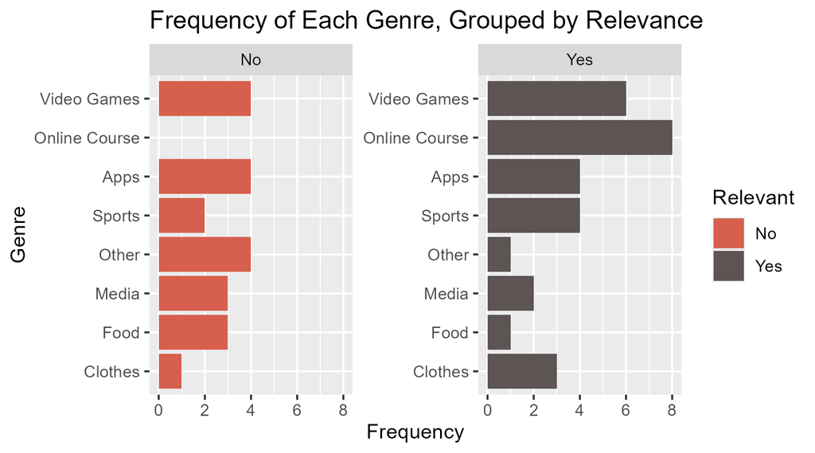

My top two highest relevant frequency genres were Video Games and Online Courses. This makes sense because I remember I would often get video game ads when watching gaming content on YouTube. Same for the online courses. I would often get online course ads when I watch educational videos on YouTube. Both gaming and educational content is what I watch the most on YouTube, so it makes sense they have the highest frequencies for the relevant Ads. The non-relevant ads are split quite evenly. It’s interesting that there weren’t any irrelevant online course ads.

.

## Boxplots of Ad Durationa Vs. Rating:

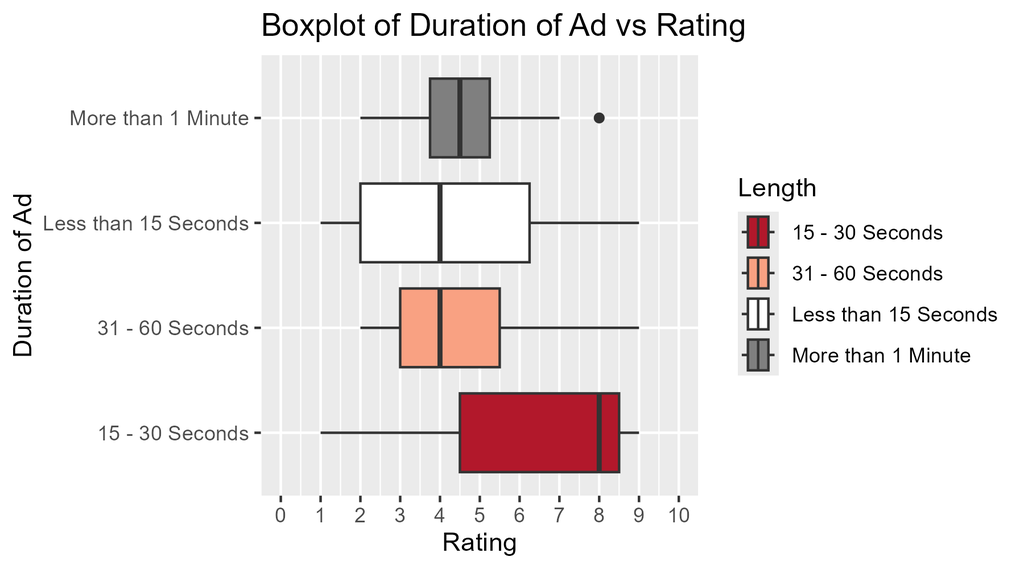

From what I remember, 15 - 30 second ads were the most common, so these had the most variability. I also think 15 - 30 second ads are the sweet spot for ad duration because it was enough time to nicely promote a product while making the viewer watch for too long. This is most likely why I rated these ads so highly. The other durations weren’t as common and had very similar ratings to each other while all having lower median ratings than the 15 - 30 second ads.

.

## Genre Frequency By Time of Day:

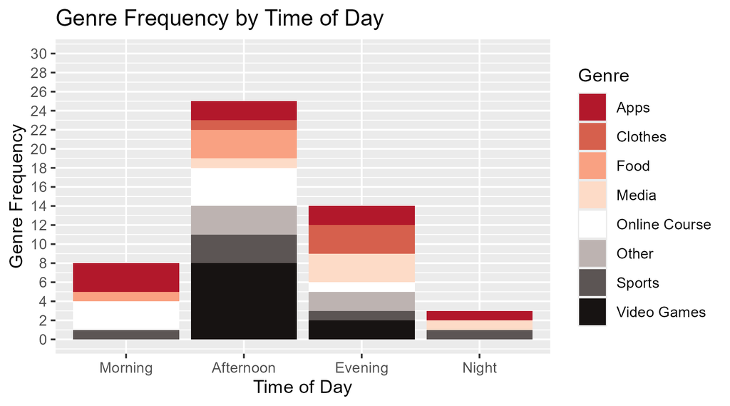

In hindsight, this plot really only tells us that I watch YouTube the most during the afternoon and evening. I thought it would be a good indication of what genres would be most popular at certain times of the day, but this all really depends on how many videos I am watching during that time of the day.